# assignment2

Author

Haoyu

## Data Wrangling

```r
library(dplyr)
library(ggplot2)
individual_data <- read.csv("https://raw.githubusercontent.com/USCbiostats/data-science-data/refs/heads/master/01_chs/chs_individual.csv")
regional_data <- read.csv("https://raw.githubusercontent.com/USCbiostats/data-science-data/refs/heads/master/01_chs/chs_regional.csv")
merged_data <- merge(individual_data, regional_data, by = "townname")
numeric <- c("agepft", "height", "weight", "bmi", "fev", "fvc", "mmef", "pm2_5_fr", "no_24hr")
categorical <- c("asthma", "active_asthma", "father_asthma", "mother_asthma", "wheeze", "hayfever", "allergy", "educ_parent", "smoke","pets", "gasstove")

nrow(merged_data)
```

```
[1] 1200
```

```r
mode_function <- function(x) {
  ux <- unique(x)
  ux[which.max(tabulate(match(x, ux)))]
}
merged_data <- merged_data %>%
  group_by(male, hispanic) %>%
  mutate(across(all_of(categorical), ~ ifelse(is.na(.), mode_function(.), .)),
         across(all_of(numeric), ~ ifelse(is.na(.), mean(., na.rm = TRUE), .))
         )

merged_data <- merged_data %>%
  mutate(obesity_level = case_when(
    bmi < 14 ~ "underweight",
    bmi >= 14 & bmi <= 22 ~ "normal",
    bmi > 22 & bmi <= 24 ~ "overweight",
    bmi > 24 ~ "obese"
  ))
obesity_summary <- merged_data %>%
  group_by(obesity_level) %>%
  summarise(min_bmi = min(bmi, na.rm = TRUE),
            max_bmi = max(bmi, na.rm = TRUE),
            total_count = n())
obesity_summary
```

```
# A tibble: 4 × 4
  obesity_level min_bmi max_bmi total_count
  <chr>           <dbl>   <dbl>       <int>
1 normal           14.0    22.0         975
2 obese            24.0    41.3         103
3 overweight       22.0    24.0          87
4 underweight      11.3    14.0          35
```

```r
merged_data <- merged_data %>%
  mutate(smoke_gas_exposure = case_when(
    smoke == 1 & gasstove == 1 ~ "Both",
    smoke == 1 ~ "Second Hand Smoke Only",
    gasstove == 1 ~ "Gas Stove Only",
    TRUE ~ "None"
  ))
summary_town <- merged_data %>%
  group_by(townname) %>%
  summarise(avg_FEV = mean(fev, na.rm = TRUE),
            sd_FEV = sd(fev, na.rm = TRUE))
summary_town
```

```
# A tibble: 12 × 3
   townname      avg_FEV sd_FEV
   <chr>           <dbl>  <dbl>
 1 Alpine          2087.   291.
 2 Atascadero      2076.   324.
 3 Lake Elsinore   2039.   304.
 4 Lake Gregory    2085.   320.
 5 Lancaster       2003.   317.
 6 Lompoc          2034.   351.
 7 Long Beach      1986.   319.
 8 Mira Loma       1985.   325.
 9 Riverside       1990.   278.
10 San Dimas       2027.   319.
11 Santa Maria     2026.   312.
12 Upland          2024.   343.
```

```r
summary_sex <- merged_data %>%
  group_by(male) %>%
  summarise(avg_FEV = mean(fev, na.rm = TRUE),
            sd_FEV = sd(fev, na.rm = TRUE))
summary_sex
```

```
# A tibble: 2 × 3
   male avg_FEV sd_FEV
  <int>   <dbl>  <dbl>
1     0   1959.   312.
2     1   2104.   308.
```

```r
summary_obesity <- merged_data %>%
  group_by(obesity_level) %>%
  summarise(avg_FEV = mean(fev, na.rm = TRUE),
            sd_FEV = sd(fev, na.rm = TRUE))
summary_obesity
```

```
# A tibble: 4 × 3
  obesity_level avg_FEV sd_FEV
  <chr>           <dbl>  <dbl>
1 normal          2000.   295.
2 obese           2266.   325.
3 overweight      2224.   317.
4 underweight     1698.   303.
```

```r
summary_smoke_gas <- merged_data %>%
  group_by(smoke_gas_exposure) %>%
  summarise(avg_FEV = mean(fev, na.rm = TRUE),
            sd_FEV = sd(fev, na.rm = TRUE))
summary_smoke_gas
```

```
# A tibble: 4 × 3
  smoke_gas_exposure     avg_FEV sd_FEV
  <chr>                    <dbl>  <dbl>
1 Both                     2025.   301.
2 Gas Stove Only           2023.   319.
3 None                     2057.   329.
4 Second Hand Smoke Only   2056.   296.
```

## Looking at the Data

1. What is the association between BMI and FEV (forced expiratory volume)?
2. What is the association between smoke and gas exposure and FEV?
3. What is the association between PM2.5 exposure and FEV?

## Visualization

1. Facet plot showing scatterplots with regression lines of BMI vs FEV by “townname”.

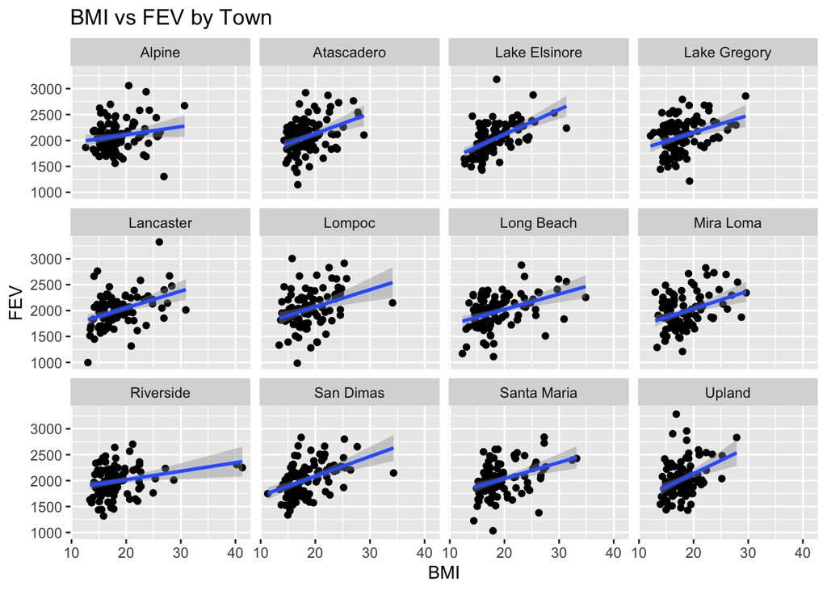

```r
ggplot(merged_data, aes(x = bmi, y = fev)) +
  geom_point() +
  geom_smooth(method = "lm") +
  facet_wrap(~ townname) +
  labs(title = "BMI vs FEV by Town", x = "BMI", y = "FEV")
```

Overall, the regression lines for all towns show some positive correlation between BMI and FEV. However, there are still differences between different regions, which may be related to other factors, such as dietary habits, environment, etc.

2. Stacked histograms of FEV by BMI category and FEV by smoke/gas exposure. Use different color schemes than the ggplot default.

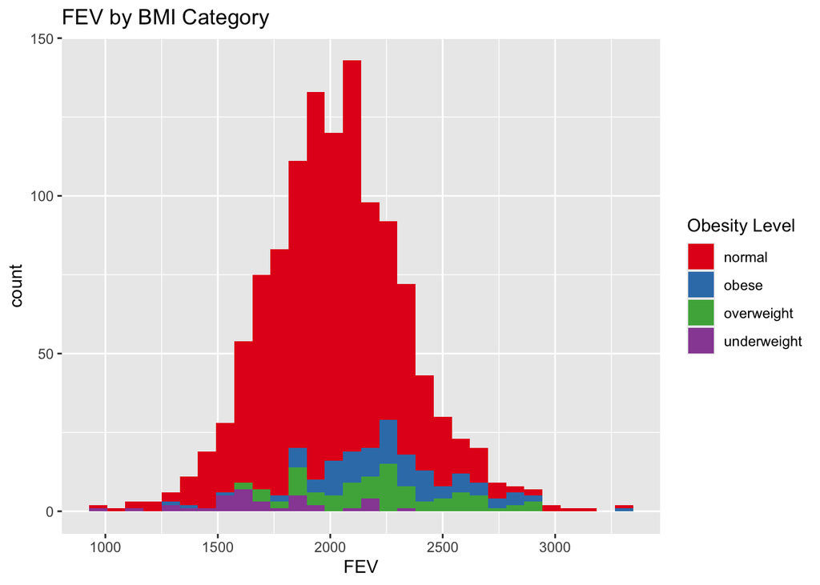

```r
ggplot(merged_data, aes(x = fev, fill = obesity_level)) +
  geom_histogram(position = "stack", bins = 30) +
  scale_fill_brewer(palette = "Set1") +
  labs(title = "FEV by BMI Category", x = "FEV", fill = "Obesity Level")
```

From the plot, FEV values for normal weight are normally distributed and the numbers make up the majority of the sample. Overweight and obese people have an overall higher FEV than normal weight people. underweight people have an overall lower FEV than normal weight people. Therefore, FEV and BMI may be positively correlated.

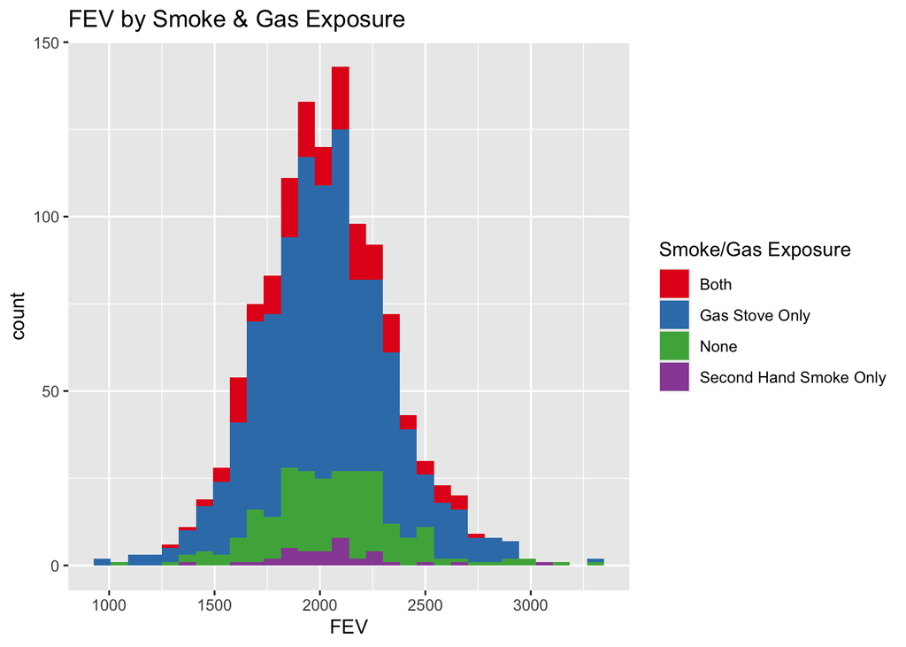

```r
ggplot(merged_data, aes(x = fev, fill = smoke_gas_exposure)) +
  geom_histogram(position = "stack", bins = 30) +
  scale_fill_brewer(palette = "Set1") +
  labs(title = "FEV by Smoke & Gas Exposure", x = "FEV", fill = "Smoke/Gas Exposure")
```

The four types of Smoke & Gas Exposure are all normally distributed, and the means are similar, only the numbers are different, which proves that there may be no correlation between FEV and Smoke & Gas Exposure.

3. Barchart of BMI by smoke/gas exposure.

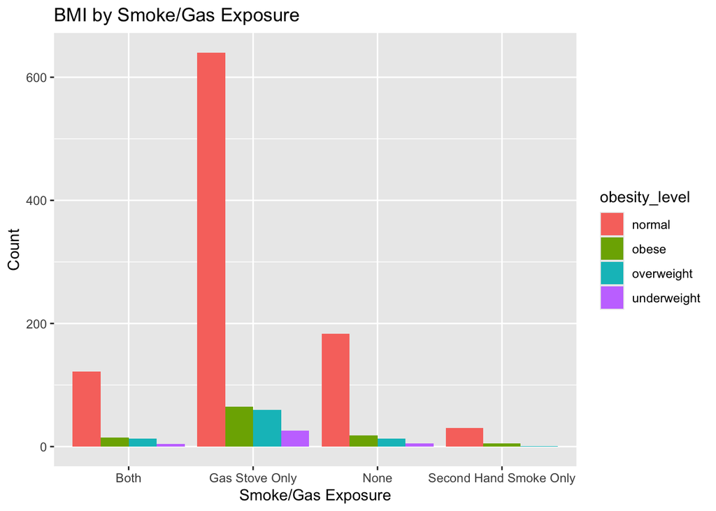

```r
ggplot(merged_data, aes(x = smoke_gas_exposure, fill = obesity_level)) +
  geom_bar(position = "dodge") +
  labs(title = "BMI by Smoke/Gas Exposure", x = "Smoke/Gas Exposure", y = "Count")
```

It can be seen most intuitively that the proportion of people who are not emitted by the two gases has a normal weight than those who absorb the two gases.

4. Statistical summary graphs of FEV by BMI and FEV by smoke/gas exposure category.

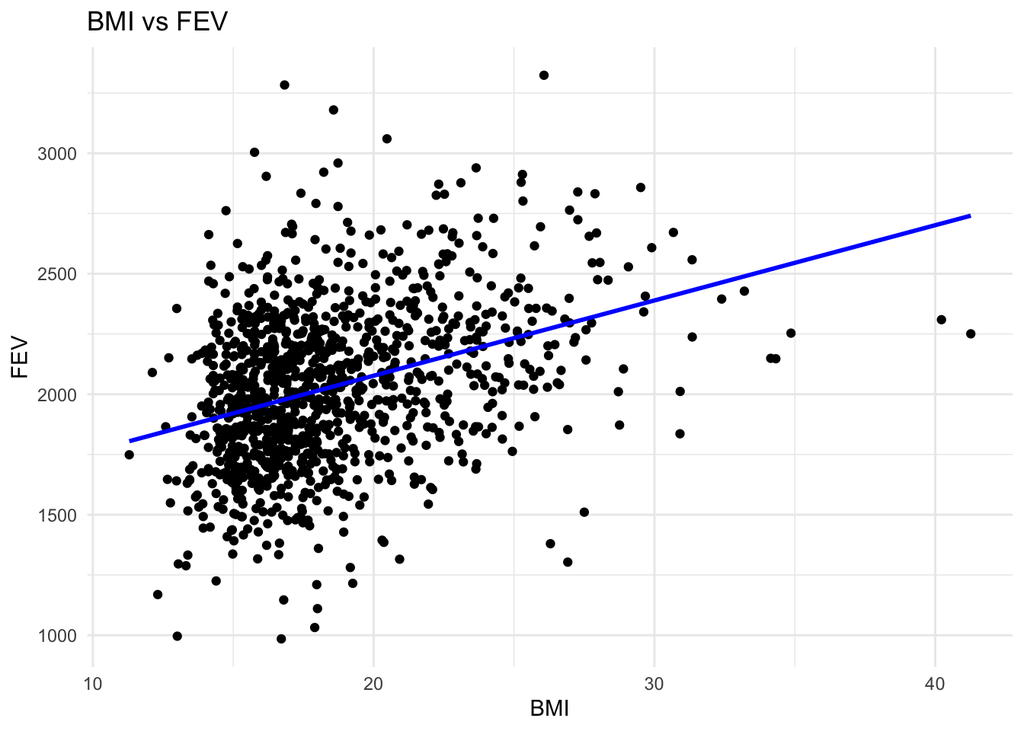

```r
library(ggplot2)
ggplot(merged_data, aes(x = bmi, y = fev)) +
  geom_point() +
  geom_smooth(method = "lm", color = "blue", se = FALSE) +
  labs(title = "BMI vs FEV",
       x = "BMI",
       y = "FEV") +
  theme_minimal()
```

```r
model_bmi_fev <- lm(fev ~ bmi, data = merged_data)
summary(model_bmi_fev)
```

```
Call:
lm(formula = fev ~ bmi, data = merged_data)

Residuals:
    Min      1Q  Median      3Q     Max
-989.47 -193.88  -11.32  179.43 1305.46

Coefficients:
            Estimate Std. Error t value Pr(>|t|)
(Intercept)  1452.46      44.49   32.65   <2e-16 ***
bmi            31.23       2.36   13.23   <2e-16 ***
---
Signif. codes:  0 '***' 0.001 '**' 0.01 '*' 0.05 '.' 0.1 ' ' 1

Residual standard error: 297.2 on 1198 degrees of freedom
Multiple R-squared:  0.1275,    Adjusted R-squared:  0.1268
F-statistic: 175.1 on 1 and 1198 DF,  p-value: < 2.2e-16
```

```r
cor(merged_data$bmi, merged_data$fev, use = "complete.obs")
```

```
[1] 0.357112
```

From the result and plot, p-value less than 0.05, which means that BMI and FEV have positive linear correlation. The obtained correlation coefficient is 0.35, which means that there is a certain correlation between the increase in BMI and the increase in FEV, but the correlation is not strong.

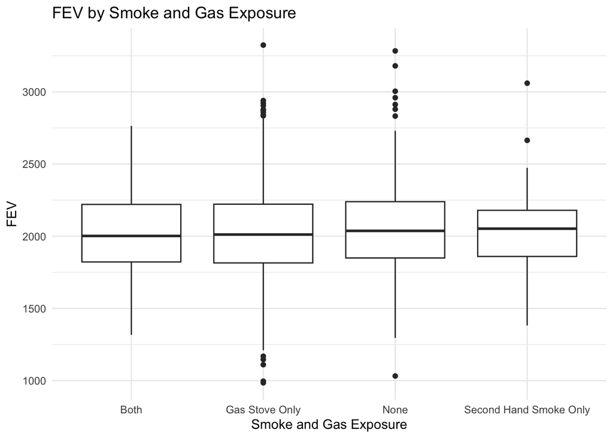

```r
ggplot(merged_data, aes(x = smoke_gas_exposure, y = fev)) +
  geom_boxplot() +
  labs(title = "FEV by Smoke and Gas Exposure",
       x = "Smoke and Gas Exposure",
       y = "FEV") +
  theme_minimal()
```

```r
anova_result <- aov(fev ~ smoke_gas_exposure, data = merged_data)
summary(anova_result)
```

```
                     Df    Sum Sq Mean Sq F value Pr(>F)
smoke_gas_exposure    3    226515   75505   0.746  0.525
Residuals          1196 121017980  101186
```

From the plot and statistical results. I don’t think there is a strong correlation between smoke and gas exposure and FEV（P-value > 0.005）

5. A leaflet map showing the concentrations of PM2.5 mass in each of the CHS communities.

```r
library(leaflet)
leaflet(data = merged_data) %>%
  addTiles() %>%
  addCircles(lng = ~lon, lat = ~lat, weight = 1,
             radius = ~pm25_mass * 300,
             popup = ~paste(townname, ":", pm25_mass),
             color = "blue", fillOpacity = 0.5)
```

[interactive chart not shown]

It can be observed that the distribution of PM2.5 mass concentration in different towns is different. Larger circles indicate higher PM2.5 values in that town, and some areas (such as Los Angeles and surrounding areas) show higher PM2.5 mass concentrations, which may be related to factors such as urbanization, traffic, etc.

6.Choose a visualization to examine whether PM2.5 mass is associated with FEV.

```r
summary(lm(fev ~ pm25_mass, data = merged_data))
```

```
Call:
lm(formula = fev ~ pm25_mass, data = merged_data)

Residuals:
     Min       1Q   Median       3Q      Max
-1070.63  -206.57   -13.33   195.87  1277.65

Coefficients:
            Estimate Std. Error t value Pr(>|t|)
(Intercept) 2073.452     19.309 107.383   <2e-16 ***
pm25_mass     -3.016      1.184  -2.548    0.011 *
---
Signif. codes:  0 '***' 0.001 '**' 0.01 '*' 0.05 '.' 0.1 ' ' 1

Residual standard error: 317.3 on 1198 degrees of freedom
Multiple R-squared:  0.005389,  Adjusted R-squared:  0.004559
F-statistic: 6.492 on 1 and 1198 DF,  p-value: 0.01096
```

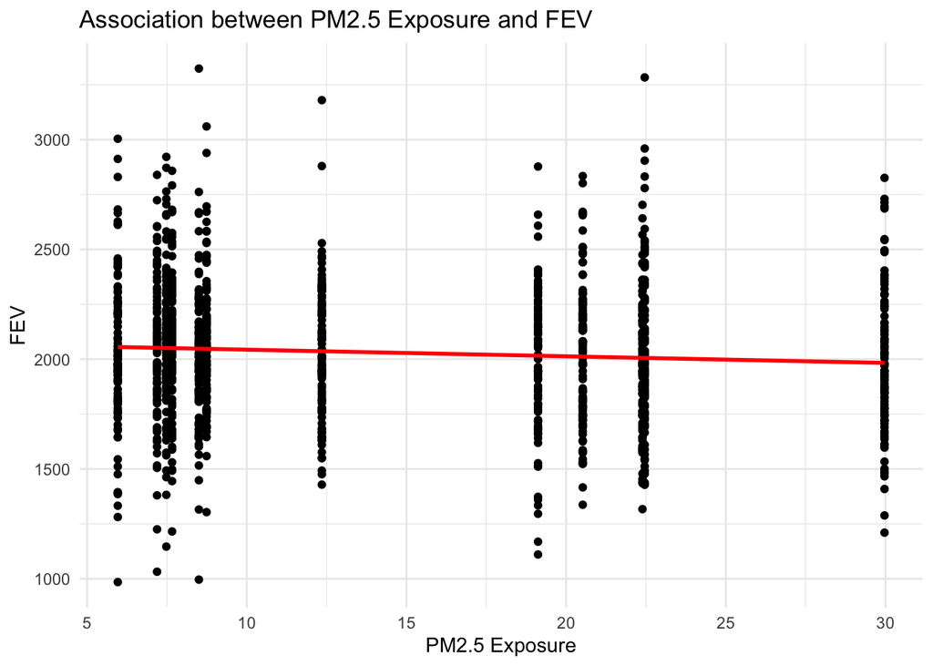

```r
ggplot(merged_data, aes(x = pm25_mass, y = fev)) +
  geom_point() +
  geom_smooth(method = "lm", color = "red", se = FALSE) +
  labs(title = "Association between PM2.5 Exposure and FEV",
       x = "PM2.5 Exposure",
       y = "FEV") +
  theme_minimal()
```

```r
city_fev <- merged_data %>%
  group_by(townname) %>%
  summarise(avg_FEV = mean(fev, na.rm = TRUE),
            pm25 = unique(pm25_mass))
summary(lm(avg_FEV ~ pm25, data = city_fev))
```

```
Call:
lm(formula = avg_FEV ~ pm25, data = city_fev)

Residuals:
    Min      1Q  Median      3Q     Max
-44.774 -22.348   2.386  20.161  40.006

Coefficients:
            Estimate Std. Error t value Pr(>|t|)
(Intercept) 2073.452     17.506  118.44   <2e-16 ***
pm25          -3.016      1.073   -2.81   0.0185 *
---
Signif. codes:  0 '***' 0.001 '**' 0.01 '*' 0.05 '.' 0.1 ' ' 1

Residual standard error: 28.76 on 10 degrees of freedom
Multiple R-squared:  0.4413,    Adjusted R-squared:  0.3854
F-statistic: 7.898 on 1 and 10 DF,  p-value: 0.01847
```

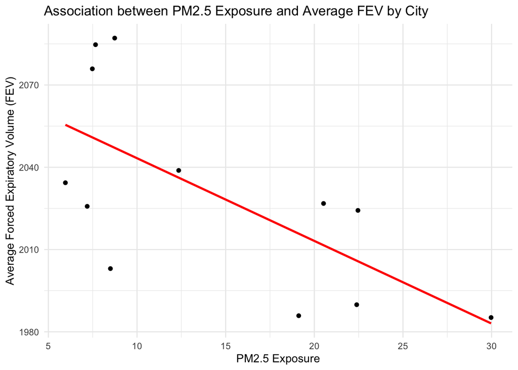

```r
ggplot(city_fev, aes(x = pm25, y = avg_FEV)) +
  geom_point() +
  geom_smooth(method = "lm", color = "red", se = FALSE) +
  labs(title = "Association between PM2.5 Exposure and Average FEV by City",
       x = "PM2.5 Exposure",
       y = "Average Forced Expiratory Volume (FEV)") +
  theme_minimal()
```

Because a region only has one PM2.5 exposure, I averaged the FEV of all people in each city and performed linear regression analysis on PM2.5. It was found that there is a negative correlation between PM2.5 exposure and FEV.